# Sleepers

Danijel Kopčinović

2020-12-03

# Introduction

In this vignette we will present the analysis of the survey data provided by Gradient Metrics. The data was gathered to find out the best marketing message for the mobile application that helps people with sleeping problems.

The parts of the message were organized into groups (“attributes”) as follows:

```
#> [1] "Attribute offer (5 values): give you the energy to unlock your fullest potential | help you lead a better life | help you sleep without more pills | improve your health for the long-run | improve your sleep sustainably"
#> [1] "Attribute outcome (3 values): breaking bad habits and creating new routines | changing your sleep mindset | empowering you to take back your sleep habits"
#> [1] "Attribute rtb (6 values): a program created just for you | cognitive behavioral therapy | daily text messages from a coach | personalized, human coaching | the support of a community of people just like you | unique daily games, challenges and exercises"
#> [1] "Attribute social_proof (4 values): a method that has helped thousands | leading researchers | professional athletes | scientific evidence"
#> [1] "Attribute duration_f (3 values): 3 months | 6 months | 12 months"
#> [1] "Attribute price_f (3 values): $20/month | $30/month | $40/month"
```

There were 892 respondents and each respondent answered 12 questions.

Each question had 4 answer options: Very unlikely | Somewhat unlikely | Somewhat likely | Very likely. Respondent chose one answer option on each question.

Let’s have a look at how many times each attribute was shown and the frequency distribution of the answers:

```
#>                                                   offer
#>  give you the energy to unlock your fullest potential:2211
#>  help you lead a better life                         :2159
#>  help you sleep without more pills                   :2094
#>  improve your health for the long-run                :2145
#>  improve your sleep sustainably                      :2095
#>
#>                                           outcome
#>  breaking bad habits and creating new routines:3559
#>  changing your sleep mindset                  :3606
#>  empowering you to take back your sleep habits:3539
#>
#>
#>
#>                                                  rtb
#>  a program created just for you                    :1819
#>  cognitive behavioral therapy                      :1862
#>  daily text messages from a coach                  :1770
#>  personalized, human coaching                      :1774
#>  the support of a community of people just like you:1727
#>  unique daily games, challenges and exercises      :1752
#>                              social_proof      duration_f        price_f
#>  a method that has helped thousands:2702   3 months :3550   $20/month:3550
#>  leading researchers               :2607   6 months :3656   $30/month:3563
#>  professional athletes             :2677   12 months:3498   $40/month:3591
#>  scientific evidence               :2718
#>
#>
#>                answer
#>  Very unlikely    :4625
#>  Somewhat unlikely:2316
#>  Somewhat likely  :2199
#>  Very likely      :1564
#>
#>
```

The attributes frequencies seem equally distributed. The answers frequencies tend to be “Very unlikely” but this can be simply a result of lack of buying intent by the respondents.

Since the survey data is actually a panel data (many answers from the same respondent) we will also check if there are some inconsistencies or strange behavior with respect to the respondents. Here is a summary of the buying intent answers for a few respondents:

```
#> # A tibble: 10 x 4
#>    response_id       min_buying_intent avg_buying_intent max_buying_intent
#>    <fct>                         <dbl>             <dbl>             <dbl>
#>  1 R_00zxXbZGxe0owBX                 1              3                    4
#>  2 R_09tDIe1d7x4Pr0Z                 3              3.75                 4
#>  3 R_0ezucdFLFLIYzK1                 1              1                    1
#>  4 R_0ieh7fHFoAgqzMl                 1              2                    3
#>  5 R_0iW8AOVhrjAj9rX                 1              1                    1
#>  6 R_0SQn8uuAEHjFqet                 1              2.33                 4
#>  7 R_0THN3dNvAvGq3Nn                 2              2.33                 3
#>  8 R_0W0F8pBDpQZPjUt                 2              3                    4
#>  9 R_10B4SZkJOzkxd7m                 1              1.17                 3
#> 10 R_10Dyr1e3m7jrhef                 2              3.17                 4
```

Some respondents seem to be more willing to buy, some less, but we can notice that e.g. respondent with id “R_0ezucdFLFLIYzK1” has the minimum and maximum buying intent 1. This means that all his/her answers were “Very unlikely”. Such respondents pose a problem for our (later) modeling because their answers provide no information about the value of attributes, they just “pull” everything towards their single answer, in this case “Very unlikely”.

Let’s see how many respondents like this one we have - always giving the same answer, grouped with respect to the buying intent options:

```
#> [1] "Always the same answer: 304"
#> [1] "All Very unlikely: 239"
#> [1] "All Somewhat unlikely: 29"
#> [1] "All Somewhat likely: 13"
#> [1] "All Very likely: 23"
```

This is quite a big number (34.08%) of people who constantly chose the same answer. Since the goal of this analysis is to find how the attributes affect the buying intent, we could say that for this group of respondents - **it doesn’t**!

If this was not panel data we could conclude that the attributes are simply not driving enough buying intent. But since we have a panel data, we tend to conclude that the respondents who always chose the same answer either did not understand the task or simply don’t care about the whole survey and didn’t think about the questions at all. In both cases their answers are invalid.

That is why we will **exclude** the answers given by these people from the further analysis. This doesn’t mean that these respondents shouldn’t be further contacted or similar (especially those that always wanted to buy), but for the sake of this analysis their answers are invalid.

*Note: we tried using all the data, but the results were much statisically weaker (e.g. much larger AIC) as expected.*

Besides the survey about the best marketing message for the mobile application, respondents also filled a personal survey, giving information about them, their sleeping problems, ways of coping with them etc.

There were 100 additional questions in this personal survey. With this additional data, we tried to segment the respondents (with respect to the answers they gave) and identify a segment/group that would be more willing to buy the mobile application.

# Experiment Data Analysis and Modelling

As a first step in our analysis of the (experimental) survey data, we will make a quick “counting” analysis: let’s see what is the average “buying intent” (from 1 = Very unlikely to 4 = Very likely) for different attributes and their values.

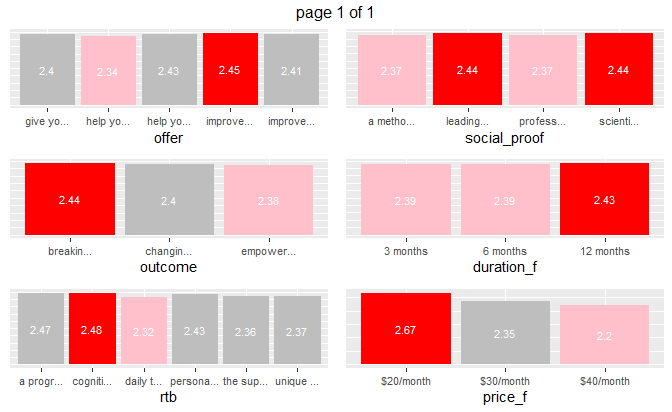

We can see that the *price* attribute levels show relatively clear trend (higher buying intent for lower price, lower buying intent for higher price). This is expected and shows that we don’t have strange behavior.

We will transform the *price* attribute to numeric to capture other possible values (which are not used in this experiment). We will also transform the *price* to its logarithm because it better captures the buyers behavior (smaller difference between higher prices than between smaller prices).

With other attributes, we can’t see such a clear trend.

Let’s also have a look at the average buying intents for different 2-combinations of attribute levels:

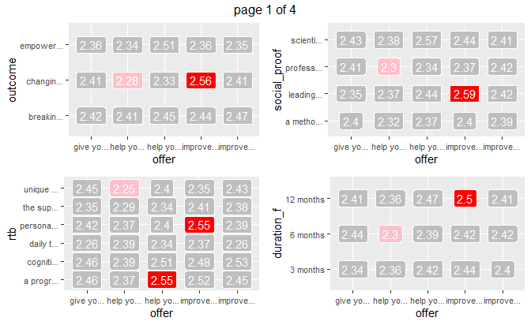

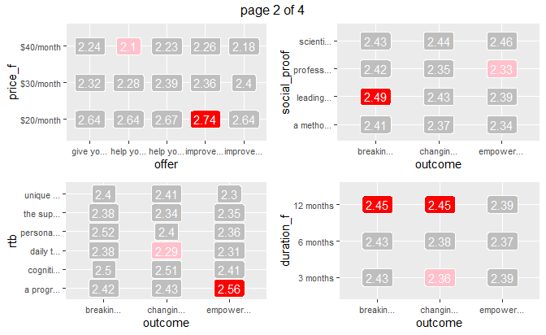

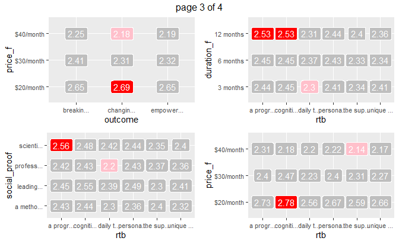

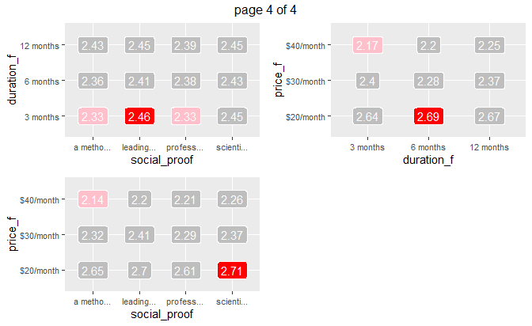

We can see that some combinations of attributes have somewhat bigger difference between the smallest (pink) and largest (red) average buying intent, e.g. *offer + rtb, offer + price, outcome + price, rtb + price…*. This indicates that some of these combinations could have an interaction effect, where one value combined with another value gives a cumulative (positive or negative) effect on the average buying intent. Thus maybe we should include these combinations in the modeling.

It is now time to build a model. Since our output variable *answer* is an ordinal variable (has comparable values), we will use an ordinal logistic regression model with *answer* as the output variable and all other variables as predictors.

We get the following summary:

```
#>                                       Value      p.value signif odds_effect
#> duration                        0.053039134 3.086881e-01            1.05447
#> offergive you the energy to un  0.000000000 1.000000e+00            1.00000
#> offerhelp you lead a better li -0.107709470 1.099992e-01            0.89789
#> offerhelp you sleep without mo  0.041222497 5.438913e-01            1.04208
#> offerimprove your health for t  0.087314569 1.982103e-01            1.09124
#> offerimprove your sleep sustai  0.006475732 9.245880e-01            1.00650
#> outcomebreaking bad habits and  0.000000000 1.000000e+00            1.00000
#> outcomechanging your sleep min -0.054506416 2.962126e-01            0.94695
#> outcomeempowering you to take  -0.079525660 1.326852e-01            0.92355
#> log_price                      -1.185945003 8.706378e-54    ***     0.30546
#> rtba program created just for   0.000000000 1.000000e+00            1.00000
#> rtbcognitive behavioral therap  0.003564656 9.609110e-01            1.00357
#> rtbdaily text messages from a  -0.255125865 6.607152e-04    ***     0.77482
#> rtbpersonalized, human coachin -0.087424392 2.387380e-01            0.91629
#> rtbthe support of a community  -0.218485690 3.619374e-03     **     0.80373
#> rtbunique daily games, challen -0.185677732 1.197853e-02      *     0.83054
#> social_proofa method that has   0.000000000 1.000000e+00            1.00000
#> social_proofleading researcher  0.096180517 1.115057e-01            1.10096
#> social_proofprofessional athle -0.023193998 7.021692e-01            0.97707
#> social_proofscientific evidenc  0.113653549 6.028549e-02      .     1.12036
#> Intercept_Very unlikely|Somewh -5.209915680 1.301633e-78    ***     0.00546
#> Intercept_Somewhat unlikely|So -3.951880629 1.481336e-47    ***     0.01922
#> Intercept_Somewhat likely|Very -2.529205852 6.622002e-21    ***     0.07972
```

Each coefficient represents attribute value (numeric or a level). Without getting into too many details about this output format, we can see (from *signif* column) that only log_price, rtbdaily text messages from a coach, rtbthe support of a community of people just like you, rtbunique daily games, challenges and exercises, social_proofscientific evidence, Intercept_Very unlikely|Somewhat unlikely, Intercept_Somewhat unlikely|Somewhat likely, Intercept_Somewhat likely|Very likely coefficients are significant (not 0 with high probability).

*duration* is not significant, so it has no impact on buying odds.

*offer* has no significant values, so it has no impact on buying odds.

*outcome* has no significant values, so it has no impact on buying odds.

*log_price* is significant with a negative coefficient, so lower log_price (meaning lower price) increases buying odds, while higher log_price (meaning higher price) decreases buying odds. This is natural and expected.

*rtb* is significant on a few values, but the coefficients are negative, so respondents prefer a program created just for you than the other values.

*social_proof* is significant on a value “scientific evidence” and the coefficient is positive, so respondents prefer “scientific evidence” than the other values.

All intercepts are significant and negative which shows that when all attributes are at 0 or at their first level, respondents tend to be more willing to buy than not to buy. So negative coefficients increase buying odds - this is contrary to the other coefficients but it’s due to some historical notation reasons. But since intercepts are not something we can control, we will focus on the non-intercept coefficients.

All coefficients are given on a logarithmic scale, so to find how they really **affect the odds** of buying intent, we have to exponentiate them. This is the “odds_effect” column. If this number is < 1, the attribute value decreases the odds of buying. If this number is > 1, the attribute value increases the odds of buying.

A lot of coefficients are non significant and a model is better if it has less parameters so we tested if we can remove some variables from the model or improve the model by adding interactions (as explained before with the graphics).

We found that we could remove *duration, offer, outcome* without losing statistical quality (AIC has actually decreased around 5). Thus our final model summary is:

```
#>                                signif                             explanation
#> log_price                         *** decrease buying odds by factor 0.305281
#> rtba program created just for                      reference level, no effect
#> rtbcognitive behavioral therap         increase buying odds by factor 1.00067
#> rtbdaily text messages from a     *** decrease buying odds by factor 0.771538
#> rtbpersonalized, human coachin        decrease buying odds by factor 0.918055
#> rtbthe support of a community      ** decrease buying odds by factor 0.800319
#> rtbunique daily games, challen     ** decrease buying odds by factor 0.825807
#> social_proofa method that has                      reference level, no effect
#> social_proofleading researcher      .  increase buying odds by factor 1.10525
#> social_proofprofessional athle        decrease buying odds by factor 0.980337
#> social_proofscientific evidenc      .  increase buying odds by factor 1.12134
#> Intercept_Very unlikely|Somewh    ***             reference buying odds < 50%
#> Intercept_Somewhat unlikely|So    ***             reference buying odds < 50%
#> Intercept_Somewhat likely|Very    ***             reference buying odds < 50%
```

Since we built an ordinal regression model, we have to check its main assumption (parallel regression assumption, a.k.a. the proportional odds assumption).

```
#> --------------------------------------------------------------------------------------------
#> Test for                         X2  df  probability
#> --------------------------------------------------------------------------------------------
#> Omnibus                              62.21   18  0
#> log_price                            37.94   2   0
#> rtbcognitive behavioral therapy              1.34    2   0.51
#> rtbdaily text messages from a coach              2.47    2   0.29
#> rtbpersonalized, human coaching              0.58    2   0.75
#> rtbthe support of a community of people just like you    1.81    2   0.4
#> rtbunique daily games, challenges and exercises      0.81    2   0.67
#> social_proofleading researchers              1.97    2   0.37
#> social_proofprofessional athletes                5.9 2   0.05
#> social_proofscientific evidence              5.84    2   0.05
#> --------------------------------------------------------------------------------------------
#>
#> H0: Parallel Regression Assumption holds
```

Looking at the probability column (it’s the 3rd number in each row, some are moved to left because of an error in tabulating the output), we can see that all coefficients except *log_price* and *Omnibus* have probability of the assumption H0 at least 0.05 (5%). This means that we can trust the H0 and the modeling assumption holds for these coefficients.

We ignore the *Omnibus* 0 probability because it’s essentially a product of all the other probabilities and thus very small by default.

*log_price* doesn’t follow the proportional odds assumption, but this is expected, because influence of the price on the buying intent is not proportional, e.g. a higher price will affect the difference between *Somewhat unlikely* and *Very unlikely* less than the difference between *Very likely* and *Somewhat likely*.

Thus altogether we can proceed with the analysis.

To check how our model works on the existing data, we ran a check with the following result:

```
#> Confusion Matrix and Statistics
#>
#>                    Reference
#> Prediction          Very unlikely Somewhat unlikely Somewhat likely Very likely
#>   Very unlikely               477               486             453         291
#>   Somewhat unlikely           508               557             553         346
#>   Somewhat likely             496               550             623         396
#>   Very likely                 276               375             414         255
#>
#> Overall Statistics
#>
#>                Accuracy : 0.271
#>                  95% CI : (0.2606, 0.2815)
#>     No Information Rate : 0.2895
#>     P-Value [Acc > NIR] : 0.9997
#>
#>                   Kappa : 0.0191
#>
#>  Mcnemar's Test P-Value : 0.6218
#>
#> Statistics by Class:
#>
#>                      Class: Very unlikely Class: Somewhat unlikely
#> Sensitivity                        0.2715                  0.28303
#> Specificity                        0.7679                  0.72347
#> Pos Pred Value                     0.2794                  0.28360
#> Neg Pred Value                     0.7607                  0.72290
#> Prevalence                         0.2490                  0.27891
#> Detection Rate                     0.0676                  0.07894
#> Detection Prevalence               0.2419                  0.27834
#> Balanced Accuracy                  0.5197                  0.50325
#>                      Class: Somewhat likely Class: Very likely
#> Sensitivity                         0.30494            0.19798
#> Specificity                         0.71235            0.81536
#> Pos Pred Value                      0.30169            0.19318
#> Neg Pred Value                      0.71549            0.81991
#> Prevalence                          0.28954            0.18254
#> Detection Rate                      0.08829            0.03614
#> Detection Prevalence                0.29266            0.18707
#> Balanced Accuracy                   0.50865            0.50667
```

## The Best Message

Summing everything up, the best marketing message would consist of:

- Duration: **12 months** (or any other value because it did not have a significant impact, but a longer value of duration would benefit the application seller)
- Offer: **improve your health for the long-run** (or any other value because it did not have a significant impact)
- Outcome: **breaking bad habits and creating new routines** (or any other value because it did not have a significant impact)
- Price: **$20/month**
- Rtb: **a program created just for you** OR **cognitive behavioral therapy**
- Social proof: **scientific evidence**

The lowest price is the least beneficial for the application seller, but when combined with the longer duration, which did not seem to bother the respondents, the overall benefit would be higher than pushing higher prices with the shorter duration.

# Respondents Segmentation and Predicting Buyers

Now we will analyze the other part of the survey data, related to demographic and other personal information.

Since the data contains quite a lot of missing information (NA), we cleaned and imputed meaningful data wherever we could.

We initially removed the *weights* variable because we didn’t understand its meaning and interpretation.

Since our main goal is to try to identify the buying influencing variables, we connected the information if a respondent is a buyer (has average buying intent as previously defined >= 3) or not with the survey data and we will try to identify the best predictors for the new *buyer* variable. With this partitioning, we have the following numbers:

```
#>
#> non-buyer     buyer
#>       683       209
```

The number of survey variables is large (99) and the number of observations (the same as number of respondents = 892) not too large, so we ran a series of Chi-squared test to see which variables show some correlation with the *buyer* variable. We kept these for the further analysis:

```
#>  [1] "d_urban"              "s_race"               "s_problem"
#>  [4] "m1_philosophy_2"      "m1_philosophy_3"      "m1_philosophy_4"
#>  [7] "m1_philosophy_5"      "m1_philosophy_6"      "m1_philosophy_7"
#> [10] "m2_attitudes_4"       "m2_attitudes_5"       "m2_attitudes_6"
#> [13] "m2_attitudes_11"      "m2_awareness_apps_4"  "m2_awareness_apps_5"
#> [16] "m2_awareness_apps_7"  "m2_awareness_apps_8"  "m2_awareness_apps_10"
#> [19] "m2_awareness_apps_11" "m2_awareness_apps_12" "m2_awareness_apps_13"
#> [22] "m2_awareness_apps_14" "hours"                "source_10"
#> [25] "source_12"            "source_17"            "behavior_5"
#> [28] "behavior_10"          "behavior_11"          "behavior_16"
#> [31] "behavior_a_1"         "behavior_a_2"         "behavior_a_3"
#> [34] "behavior_a_4"         "behavior_a_5"         "behavior_a_8"
#> [37] "behavior_a_9"         "behavior_a_10"        "behavior_a_12"
#> [40] "behavior_a_13"        "interst_cbt"          "past_coach"
#> [43] "interest_coach"       "d_h_hnumber"          "d_parent"
#> [46] "d_child_infant"       "d_child_young"        "d_child_older"
#> [49] "d_politics"           "d_political_view"     "d_employment"
#> [52] "d_work_schedule"      "d_work_hours"         "s_age"
```

Another way to see which variables could lead to higher buying probability would be to simply count the number of buyers in different groups, defined by different variables and their levels. Here are the results of such counting analysis, where we kept only the groups with at least 50% of buyers:

```
#>                ATT_NAME            ATT_VALUE BUYERS PROB_BUYER_PERC
#> 1       m1_philosophy_2       Strongly agree     54              61
#> 2       m1_philosophy_6       Strongly agree     74              52
#> 3   m2_awareness_apps_4                Omada     33              75
#> 4   m2_awareness_apps_5              Ligonvo     19              66
#> 5  m2_awareness_apps_10                Whoop     29              64
#> 6  m2_awareness_apps_12            Oura ring     31              63
#> 7  m2_awareness_apps_13              Sleepio     35              76
#> 8           behavior_10 Visited a sleep clin     24              52
#> 9           behavior_11 Read a self-help boo     37              61
#> 10         behavior_a_1      Very successful     15              88
#> 11         behavior_a_2      Very successful     14              58
#> 12         behavior_a_4      Very successful     14              67
#> 13         behavior_a_5      Very successful     12              67
#> 14         behavior_a_8      Very successful     13              76
#> 15         behavior_a_9      Very successful     15              94
#> 16         behavior_a_9  Somewhat successful     18              69
#> 17        behavior_a_10      Very successful     12              75
#> 18        behavior_a_12      Very successful     15              58
#> 19        behavior_a_13      Very successful     21              64
#> 20          interst_cbt      Very interested    104              54
#> 21           past_coach                  Yes    106              61
#> 22       interest_coach      Very interested    104              60
#> 23       d_child_infant                  One     52              58
#> 24       d_child_infant                  Two     21              62
#> 25        d_child_young                  One     74              51
#> 26        d_child_young                  Two     21              52
#> 27        d_child_older                  One     57              53
#> 28      d_work_schedule Rotating work schedu      6              55
```

If the application seller has ability to target the groups defined with above attributes and values, then it is probably the best way to go - these are e.g. people who already used a sleep-helping app, visited a sleep clinic, had a coach that helped them before etc.

But realistically, unless really many people fill the survey as in this project, it is hard to find the members of many of the groups above. Therefore, we will concentrate on more general variables/groups, that could be targeted with e.g. online ads or similar.

## Predicting Buyers

Continuing the discussion in the previous section, we decided to concentrate on the following attributes: *d_urban, s_gender, s_race, d_education, s_hhincome, m2_awareness_apps_1, m2_awareness_apps_4, m2_awareness_apps_5, m2_awareness_apps_6, m2_awareness_apps_7, m2_awareness_apps_8, m2_awareness_apps_9, m2_awareness_apps_10, m2_awareness_apps_11, m2_awareness_apps_12, m2_awareness_apps_13, m2_awareness_apps_14, d_marital, d_h_hnumber, d_parent, d_child_infant, d_child_young, d_child_older, d_politics, d_political_view, d_employment, d_work_schedule, d_work_hours, s_region, s_age*. These variables represent either some general demography and could be targeted via e.g. online ads (“if you have a sleeping problem, try our app”) or sleep-helping apps awareness and could again be targeted via application stores (to those that downloaded some app - “try our app”).

Now we’re set up to build a model that will try to predict if a respondent is a buyer or not from the variables/answers given. We get the following summary (we show only significant estimates because there are too many to show them all):

```
#>                                  Estimate     Pr...z.. signif odds_effect
#> d_urbanSuburban (An area that  -0.8385959 0.0020009571     **      0.4323
#> d_urbanRural (An area that is  -0.6401208 0.0903878429      .      0.5272
#> s_raceHispanic or Latino       -0.9900945 0.0915836456      .      0.3715
#> m2_awareness_apps_10Whoop       1.2560054 0.0099507591     **      3.5114
#> m2_awareness_apps_11Sleep qual  0.7983416 0.0031712341     **      2.2219
#> m2_awareness_apps_13Sleepio     1.1844105 0.0168012672      *      3.2688
#> m2_awareness_apps_14Not applic -1.5333528 0.0101511505      *      0.2158
#> d_h_hnumber6+                  -1.8437959 0.0243780375      *      0.1582
#> d_child_infantOne               0.6758405 0.0907099093      .      1.9657
#> d_politicsIndependent          -1.1812967 0.0071939594     **      0.3069
#> d_politicsOther                -1.3651605 0.0675601489      .      0.2553
#> d_political_viewSomewhat liber -0.6984565 0.0934480789      .      0.4974
#> d_employmentWorking part time  -0.8902819 0.0596779191      .      0.4105
#> d_employmentRetired            -2.8414306 0.0960037325      .      0.0583
#> d_work_scheduleShift work sche -1.6188636 0.0301880265      *      0.1981
#> s_age46-64                     -1.5832454 0.0005626454    ***      0.2053
```

As with the experimental data before, we will try to reduce the number of variables without losing statistical quality. We get:

```
#>                                  Estimate     Pr...z.. signif odds_effect
#> (Intercept)                     1.4798145 2.343868e-04    ***       4.392
#> d_urbanSuburban (An area that  -0.9752582 3.440902e-05    ***       0.377
#> d_urbanRural (An area that is  -0.8030382 1.736679e-02      *       0.448
#> m2_awareness_apps_9FitBit      -0.4520980 5.257214e-02      .       0.636
#> m2_awareness_apps_10Whoop       1.2445217 3.546847e-03     **       3.471
#> m2_awareness_apps_11Sleep qual  0.7124368 2.780803e-03     **       2.039
#> m2_awareness_apps_12Oura ring   0.9236349 2.676268e-02      *       2.518
#> m2_awareness_apps_13Sleepio     1.2856739 2.624567e-03     **       3.617
#> m2_awareness_apps_14Not applic -1.8609407 5.364455e-04    ***       0.156
#> d_parentNo                     -1.0627231 5.397387e-06    ***       0.346
#> d_politicsIndependent          -1.2617349 3.696659e-04    ***       0.283
#> d_politicsOther                -1.6657383 1.671525e-02      *       0.189
#> d_work_scheduleFlexible work s -0.5942218 5.282630e-02      .       0.552
#> d_work_scheduleShift work sche -1.2294995 4.193273e-02      *       0.292
#> d_work_scheduleDon’t know / no -0.9605139 1.450912e-04    ***       0.383
#> s_age46-64                     -1.5654010 8.562276e-06    ***       0.209
#> s_age65+                       -2.0658720 1.406816e-03     **       0.127
```

Before continuing with the analysis of the coefficients, we check how does our model work on the existing data:

```
#> fitting null model for pseudo-r2
#>          llh      llhNull           G2     McFadden         r2ML         r2CU
#> -280.9903309 -485.6279425  409.2752231    0.4213876    0.3679765    0.5546850
#> Confusion Matrix and Statistics
#>
#>            Reference
#> Prediction  non-buyer buyer
#>   non-buyer       638    78
#>   buyer            45   131
#>
#>                Accuracy : 0.8621
#>                  95% CI : (0.8377, 0.8841)
#>     No Information Rate : 0.7657
#>     P-Value [Acc > NIR] : 4.127e-13
#>
#>                   Kappa : 0.5934
#>
#>  Mcnemar's Test P-Value : 0.00391
#>
#>             Sensitivity : 0.9341
#>             Specificity : 0.6268
#>          Pos Pred Value : 0.8911
#>          Neg Pred Value : 0.7443
#>              Prevalence : 0.7657
#>          Detection Rate : 0.7152
#>    Detection Prevalence : 0.8027
#>       Balanced Accuracy : 0.7805
#>
#>        'Positive' Class : non-buyer
#>
```

McFadden’s pseudo R-squared, accuracy and other checks are ok, so we can continue with our analysis.

Now that we have coefficients of all variables that occurred in the survey, we can pull out the values of each variable that “pull” the buying odds in the positive direction (compared to other values in the same attribute):

```
#>                personal                value odds_effect
#> 1               d_urban Urban (An area that     1.000000
#> 2   m2_awareness_apps_6                 None    1.000000
#> 3   m2_awareness_apps_6                 Calm    1.000000
#> 4   m2_awareness_apps_9                 None    1.000000
#> 5  m2_awareness_apps_10                Whoop    3.471274
#> 6  m2_awareness_apps_11        Sleep quality    2.038954
#> 7  m2_awareness_apps_12            Oura ring    2.518428
#> 8  m2_awareness_apps_13              Sleepio    3.617105
#> 9  m2_awareness_apps_14                 None    1.000000
#> 10             d_parent                  Yes    1.000000
#> 11           d_politics      Strong Democrat    1.000000
#> 12           d_politics             Democrat    1.000000
#> 13           d_politics           Republican    1.000000
#> 14           d_politics    Strong Republican    1.000000
#> 15      d_work_schedule Fixed work schedule     1.000000
#> 16      d_work_schedule Rotating work schedu    1.000000
#> 17                s_age                18-30    1.000000
#> 18                s_age                31-45    1.000000
```

The results intuitively make sense: higher probability buyers are

- urban (more sleeping problems, more used to using mobile apps),
- users of other sleep helping apps (Whoop, Sleep quality, Oura ring, Sleepio),
- not users of the FitBit app,
- parents,
- with fixed working schedule (a lot of work),
- with rotating work schedule (repetitive changes, harder to get a good sleeping habit),
- younger (more inclined to using mobile apps for help).

**So the best approach to find buyers in general would be to target people that satisfy the values of the attributes above.**

## Clustering Respondents

We also tried to cluster the respondents according to the answers given in the survey to see if we can correlate some segments with the buyers. This was more of a check of the results above because we answered the business question.

The first step in clustering is to define the number of clusters we wish to create. This is usually done with a so called “elbow method”. A good guess for the number of clusters is picked at a point where a sudden change in direction (an “elbow”) can be seen in the graphs below:

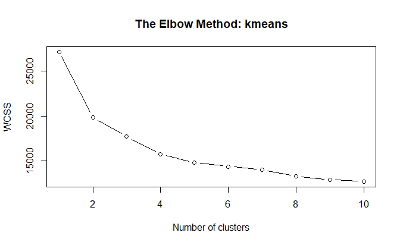

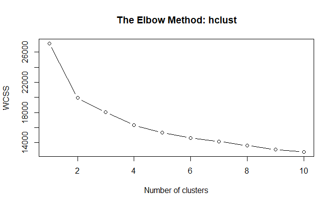

The “WCSS” is a total sum of squares within all the clusters. Where the sudden change in direction of the graph occurs is a probable good guess of the real number of clusters in the data.

The graphs above show an “elbow” only for 2 clusters so we proceed with 2 clusters. We tried 2 clustering methods - k-means and hierarchical clustering. k-means turned out better in a sense of lesser total sum of squares within all the clusters.

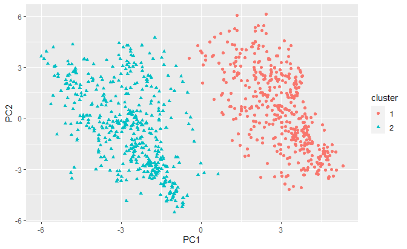

As the image above shows, 2 clusters are well separated. Let’s see how do the clusters correspond to buyers:

```
#>
#>               1   2
#>   non-buyer 268 415
#>   buyer     163  46
```

Now we will compare the variables identified as the most important in predicting buyers in the previous section with respect to the clusters we just created. These variables (and their levels) are:

```
#> [1] "d_urban:Urban (An area that is commonly within a town or city with a large population)"
#> [2] "m2_awareness_apps_9:None"
#> [3] "m2_awareness_apps_10:Whoop"
#> [4] "m2_awareness_apps_11:Sleep quality"
#> [5] "m2_awareness_apps_12:Oura ring"
#> [6] "m2_awareness_apps_13:Sleepio"
#> [7] "m2_awareness_apps_14:None"
#> [8] "d_parent:Yes"
```

We want to see if there are some patterns that connect the clusters and the variables above. Here is a list of bar-charts showing the distribution of each variable with respect to the clusters:

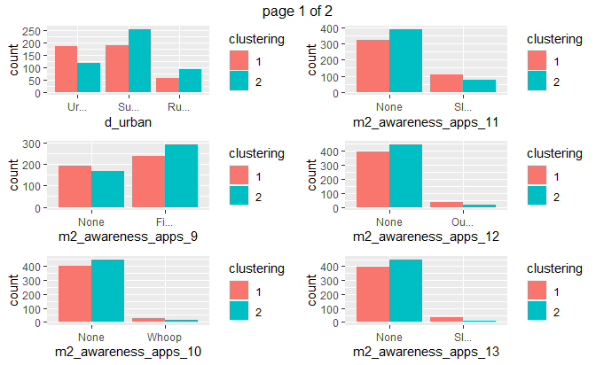

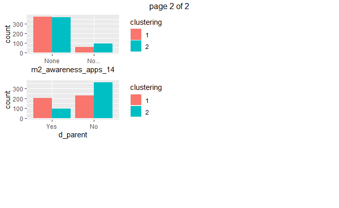

We can see e.g.:

- *d_urban:Urban (An area that is commonly within a town or city with a large population)* has more cluster 1 respondents, which are higher probability buyers. This is consistent with previous conclusions.
- *m2_awareness_apps_9:None* has more cluster 1 respondents, which are higher probability buyers. This is consistent with previous conclusions.
- *m2_awareness_apps_10:Whoop* has more cluster 1 respondents, which are higher probability buyers. This is consistent with previous conclusions.
- *m2_awareness_apps_11:Sleep quality* has more cluster 1 respondents, which are higher probability buyers. This is consistent with previous conclusions.
- *m2_awareness_apps_12:Oura ring* has more cluster 1 respondents, which are higher probability buyers. This is consistent with previous conclusions.
- *m2_awareness_apps_13:Sleepio* has more cluster 1 respondents, which are higher probability buyers. This is consistent with previous conclusions.
- *m2_awareness_apps_14:None* has more cluster 1 respondents, which are higher probability buyers. This is consistent with previous conclusions.
- *d_parent:Yes* has more cluster 1 respondents, which are higher probability buyers. This is consistent with previous conclusions.

We can conclude that all our previous conclusions and the new clustering support each other in the “prediction” of buyers.

We also looked at the clustering with respect to the other variables that previously turned insignificant, in hope that we could find some additional positive predictors for buyers (from the clustering itself).

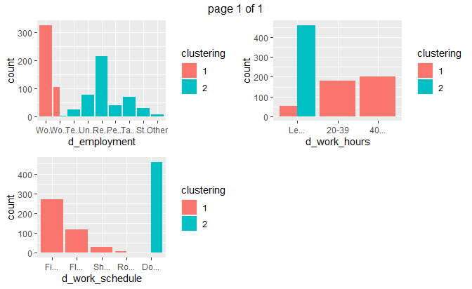

Although some values have clearly more cluster 1 respondents and thus could have a positive influence on the buying odds, we tend to trust the real prediction model that we built before because clustering algorithm was not run as a model for predicting the buyers (but finding similarities) and because there are not many clustering differences, except for those already matched with the prediction model. So we will keep the buying predictors from the prediction model.

## The Best Target Public

All together, here are all the variables and levels that have a high probability of a positive effect on buying odds:

- *d_urban:Urban (An area that is commonly within a town or city with a large population)*,
- *m2_awareness_apps_9:None*,
- *m2_awareness_apps_10:Whoop*,
- *m2_awareness_apps_11:Sleep quality*,
- *m2_awareness_apps_12:Oura ring*,
- *m2_awareness_apps_13:Sleepio*,
- *m2_awareness_apps_14:None*,
- *d_parent:Yes*.

# Discussion

If the survey was choice based instead of ratings based we could make a better analysis, e.g. we would avoid having respondents that always pick the same answer.

It would be better if we had more choice experiment survey data instead of so many demographic survey data (100 variables).

If we had clearer explanations on the survey variables, perhaps it could help in better predictions.